# Loan Status Prediction

This notebook loads the loan dataset, cleans and preprocesses it, trains multiple classification models, tunes them with GridSearchCV, and exports the best model along with the encoders and scaler for later use in a Streamlit web app.

## Import Libraries

```python
import pandas as pd
import numpy as np
import pickle
from pathlib import Path
import matplotlib.pyplot as plt
import seaborn as sns
import os

from sklearn.preprocessing import LabelEncoder, StandardScaler
from sklearn.model_selection import train_test_split, GridSearchCV
from sklearn.linear_model import LogisticRegression
from sklearn.ensemble import RandomForestClassifier
from sklearn.svm import SVC
from sklearn.neighbors import KNeighborsClassifier
from xgboost import XGBClassifier
from sklearn.metrics import accuracy_score, confusion_matrix, classification_report

pd.set_option("display.max_columns", None)
sns.set_style("darkgrid")

BASE_DIR=Path.cwd().parent
DATA_DIR=BASE_DIR/'data'
CHARTS_DIR=BASE_DIR/'charts'
```

## Load Dataset

```python
df = pd.read_csv(DATA_DIR/'raw'/'loan_dataset.csv')
df.head()
```

|  | Loan_ID | Gender | Married | Dependents | Education | Self_Employed | ApplicantIncome | CoapplicantIncome | LoanAmount | Loan_Amount_Term | Credit_History | Property_Area | Loan_Status |
| --- | --- | --- | --- | --- | --- | --- | --- | --- | --- | --- | --- | --- | --- |
| 0 | LP001002 | Male | No | 0 | Graduate | No | 5849 | 0.0 | NaN | 360.0 | 1.0 | Urban | Y |
| 1 | LP001003 | Male | Yes | 1 | Graduate | No | 4583 | 1508.0 | 128.0 | 360.0 | 1.0 | Rural | N |
| 2 | LP001005 | Male | Yes | 0 | Graduate | Yes | 3000 | 0.0 | 66.0 | 360.0 | 1.0 | Urban | Y |
| 3 | LP001006 | Male | Yes | 0 | Not Graduate | No | 2583 | 2358.0 | 120.0 | 360.0 | 1.0 | Urban | Y |
| 4 | LP001008 | Male | No | 0 | Graduate | No | 6000 | 0.0 | 141.0 | 360.0 | 1.0 | Urban | Y |

```python
print(f"Rows: {df.shape[0]}")
print(f"Cols: {df.shape[1]}")
```

```
Rows: 614
Cols: 13
```

```python
df.info()
```

```
<class 'pandas.core.frame.DataFrame'>
RangeIndex: 614 entries, 0 to 613
Data columns (total 13 columns):
 #   Column             Non-Null Count  Dtype
---  ------             --------------  -----
 0   Loan_ID            614 non-null    object
 1   Gender             601 non-null    object
 2   Married            611 non-null    object
 3   Dependents         599 non-null    object
 4   Education          614 non-null    object
 5   Self_Employed      582 non-null    object
 6   ApplicantIncome    614 non-null    int64
 7   CoapplicantIncome  614 non-null    float64
 8   LoanAmount         592 non-null    float64
 9   Loan_Amount_Term   600 non-null    float64
 10  Credit_History     564 non-null    float64
 11  Property_Area      614 non-null    object
 12  Loan_Status        614 non-null    object
dtypes: float64(4), int64(1), object(8)
memory usage: 62.5+ KB
```

```python
df.describe()
```

|  | ApplicantIncome | CoapplicantIncome | LoanAmount | Loan_Amount_Term | Credit_History |
| --- | --- | --- | --- | --- | --- |
| count | 614.000000 | 614.000000 | 592.000000 | 600.00000 | 564.000000 |
| mean | 5403.459283 | 1621.245798 | 146.412162 | 342.00000 | 0.842199 |
| std | 6109.041673 | 2926.248369 | 85.587325 | 65.12041 | 0.364878 |
| min | 150.000000 | 0.000000 | 9.000000 | 12.00000 | 0.000000 |
| 25% | 2877.500000 | 0.000000 | 100.000000 | 360.00000 | 1.000000 |
| 50% | 3812.500000 | 1188.500000 | 128.000000 | 360.00000 | 1.000000 |
| 75% | 5795.000000 | 2297.250000 | 168.000000 | 360.00000 | 1.000000 |
| max | 81000.000000 | 41667.000000 | 700.000000 | 480.00000 | 1.000000 |

## Exploratory Data Analysis and Visualization

### Target Variable Distribution

```
Chart saved to: p:\loan default prediction\charts\count_of_loans_approved.png
```

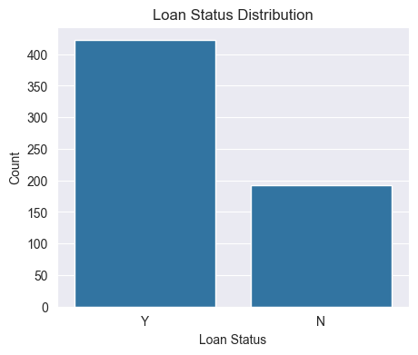

```python
plt.figure(figsize=(5, 4))
sns.countplot(x="Loan_Status", data=df)
plt.title("Loan Status Distribution")
plt.xlabel("Loan Status")
plt.ylabel("Count")
save_file=os.path.join(CHARTS_DIR, 'count_of_loans_approved.png')
plt.savefig(save_file, dpi=300, bbox_inches='tight')
print(f"Chart saved to: {save_file}")
plt.show()
```

```python
df["Loan_Status"].value_counts(normalize=True)*100
```

```
Loan_Status
Y    68.729642
N    31.270358
Name: proportion, dtype: float64
```

### Missing Values Overview

```
Chart saved to: p:\loan default prediction\charts\missing_values_heatmap.png
```

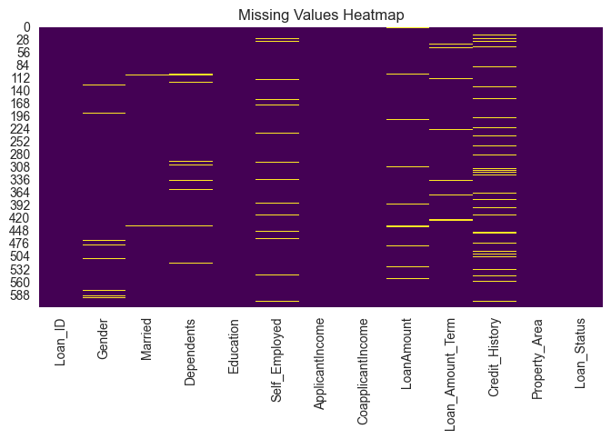

```python
plt.figure(figsize=(8, 4))
sns.heatmap(df.isnull(), cbar=False, cmap="viridis")
plt.title("Missing Values Heatmap")
save_file=os.path.join(CHARTS_DIR, 'missing_values_heatmap.png')
plt.savefig(save_file, dpi=300, bbox_inches='tight')
print(f"Chart saved to: {save_file}")
plt.show()
```

## Check Missing Values

```python
df.isnull().sum()
```

```
Loan_ID               0
Gender               13
Married               3
Dependents           15
Education             0
Self_Employed        32
ApplicantIncome       0
CoapplicantIncome     0
LoanAmount           22
Loan_Amount_Term     14
Credit_History       50
Property_Area         0
Loan_Status           0
dtype: int64
```

We have missing values in both categorical and numerical columns.

- Categorical columns will be filled using the **mode**.
- Numerical columns will be filled using the **median**.

```python
categorical_cols = ["Gender", "Married", "Dependents", "Self_Employed", "Credit_History"]
numerical_cols = ["LoanAmount", "Loan_Amount_Term"]

print("Categorical columns:", categorical_cols)
print("Numerical columns:", numerical_cols)
```

```
Categorical columns: ['Gender', 'Married', 'Dependents', 'Self_Employed', 'Credit_History']
Numerical columns: ['LoanAmount', 'Loan_Amount_Term']
```

```python
for col in categorical_cols:
    df[col] = df[col].fillna(df[col].mode()[0])

for col in numerical_cols:
    df[col] = df[col].fillna(df[col].median())

df.isnull().sum()
```

```
Loan_ID              0
Gender               0
Married              0
Dependents           0
Education            0
Self_Employed        0
ApplicantIncome      0
CoapplicantIncome    0
LoanAmount           0
Loan_Amount_Term     0
Credit_History       0
Property_Area        0
Loan_Status          0
dtype: int64
```

## Drop Irrelevant Columns

```python
# Loan_ID is just an identifier, it does not help in prediction
df = df.drop(columns=["Loan_ID"])
df.head()
```

|  | Gender | Married | Dependents | Education | Self_Employed | ApplicantIncome | CoapplicantIncome | LoanAmount | Loan_Amount_Term | Credit_History | Property_Area | Loan_Status |
| --- | --- | --- | --- | --- | --- | --- | --- | --- | --- | --- | --- | --- |
| 0 | Male | No | 0 | Graduate | No | 5849 | 0.0 | 128.0 | 360.0 | 1.0 | Urban | Y |
| 1 | Male | Yes | 1 | Graduate | No | 4583 | 1508.0 | 128.0 | 360.0 | 1.0 | Rural | N |
| 2 | Male | Yes | 0 | Graduate | Yes | 3000 | 0.0 | 66.0 | 360.0 | 1.0 | Urban | Y |
| 3 | Male | Yes | 0 | Not Graduate | No | 2583 | 2358.0 | 120.0 | 360.0 | 1.0 | Urban | Y |
| 4 | Male | No | 0 | Graduate | No | 6000 | 0.0 | 141.0 | 360.0 | 1.0 | Urban | Y |

### Categorical Features vs Loan Status

```
Chart saved to: p:\loan default prediction\charts\categorical_vs_loan_status.png
```

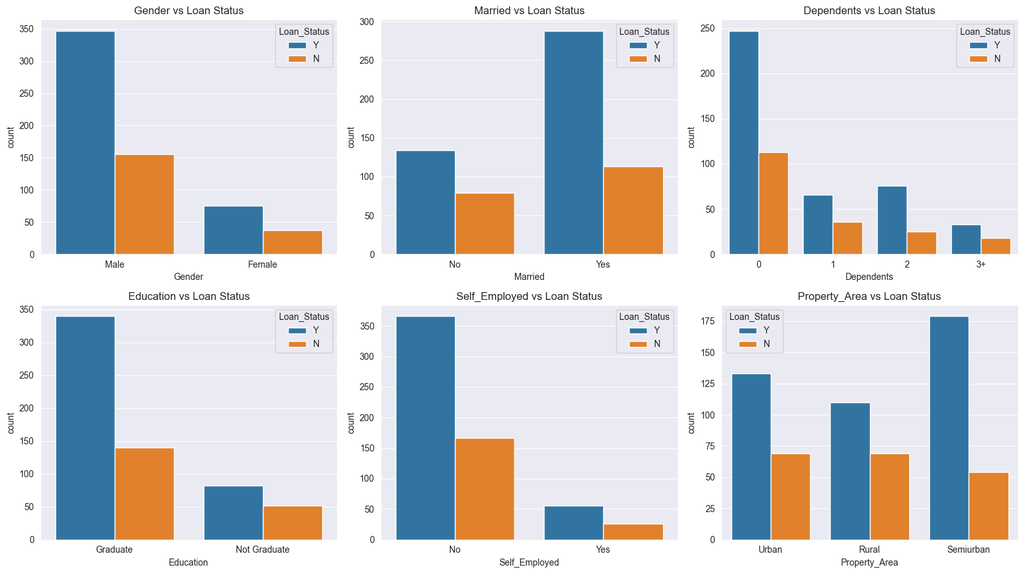

```python
cat_cols_eda = ["Gender", "Married", "Dependents", "Education", "Self_Employed", "Property_Area"]

fig, axes = plt.subplots(2, 3, figsize=(16, 9))
axes = axes.flatten()

for i, col in enumerate(cat_cols_eda):
    sns.countplot(x=col, hue="Loan_Status", data=df, ax=axes[i])
    axes[i].set_title(f"{col} vs Loan Status")

plt.tight_layout()
save_file=os.path.join(CHARTS_DIR, 'categorical_vs_loan_status.png')
plt.savefig(save_file, dpi=300, bbox_inches='tight')
print(f"Chart saved to: {save_file}")
plt.show()
```

### Numerical Features Distribution

```
Chart saved to: p:\loan default prediction\charts\numerical_features_distribution.png
```

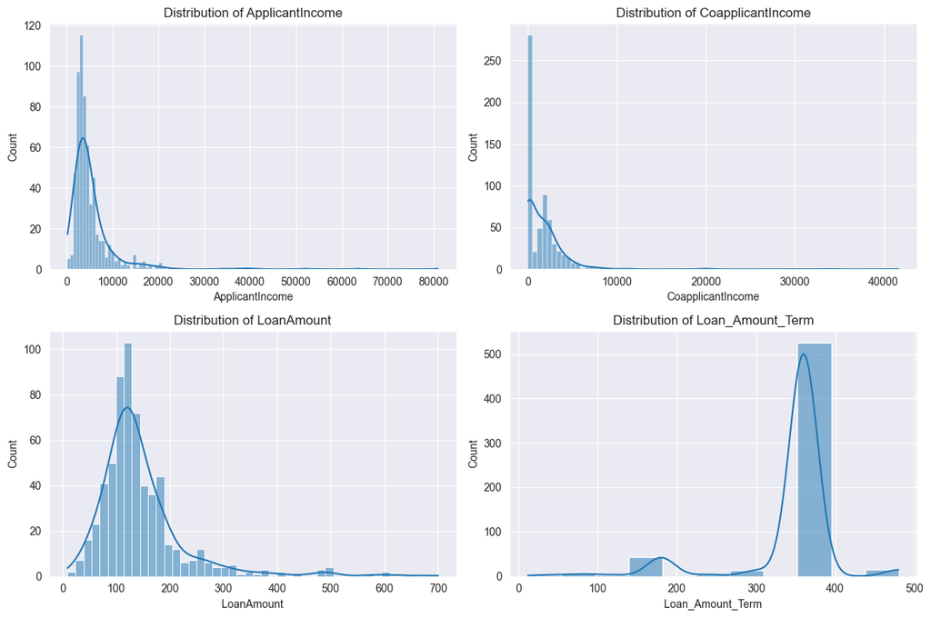

```python
num_cols_eda = ["ApplicantIncome", "CoapplicantIncome", "LoanAmount", "Loan_Amount_Term"]

fig, axes = plt.subplots(2, 2, figsize=(12, 8))
axes = axes.flatten()

for i, col in enumerate(num_cols_eda):
    sns.histplot(df[col], kde=True, ax=axes[i])
    axes[i].set_title(f"Distribution of {col}")

plt.tight_layout()
save_file=os.path.join(CHARTS_DIR, 'numerical_features_distribution.png')
plt.savefig(save_file, dpi=300, bbox_inches='tight')
print(f"Chart saved to: {save_file}")
plt.show()
```

### Outlier Check with Boxplots

```
Chart saved to: p:\loan default prediction\charts\outliers.png
```

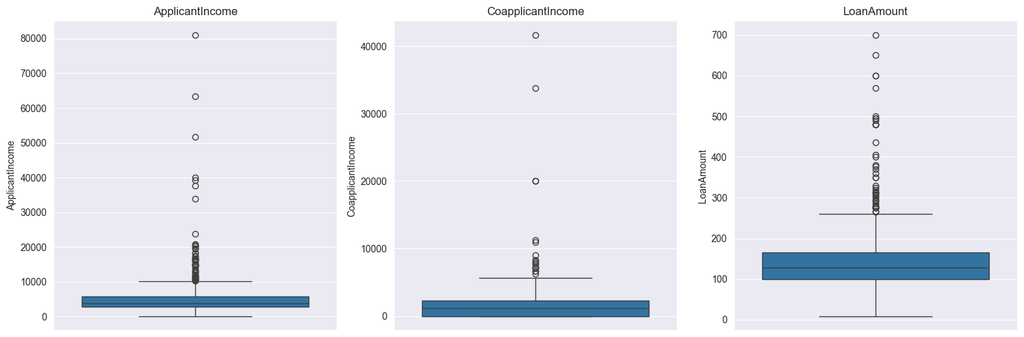

```python
fig, axes = plt.subplots(1, 3, figsize=(15, 5))

sns.boxplot(y=df["ApplicantIncome"], ax=axes[0])
axes[0].set_title("ApplicantIncome")

sns.boxplot(y=df["CoapplicantIncome"], ax=axes[1])
axes[1].set_title("CoapplicantIncome")

sns.boxplot(y=df["LoanAmount"], ax=axes[2])
axes[2].set_title("LoanAmount")

plt.tight_layout()
save_file=os.path.join(CHARTS_DIR, 'outliers.png')
plt.savefig(save_file, dpi=300, bbox_inches='tight')
print(f"Chart saved to: {save_file}")
plt.show()
```

We can see some outliers in `ApplicantIncome`, `CoapplicantIncome` and `LoanAmount`. Since tree based and distance based models can be sensitive to outliers, we keep this in mind, but for this simple project we proceed without removing them.

### Correlation Heatmap

```
Chart saved to: p:\loan default prediction\charts\correlation_heatmap.png
```

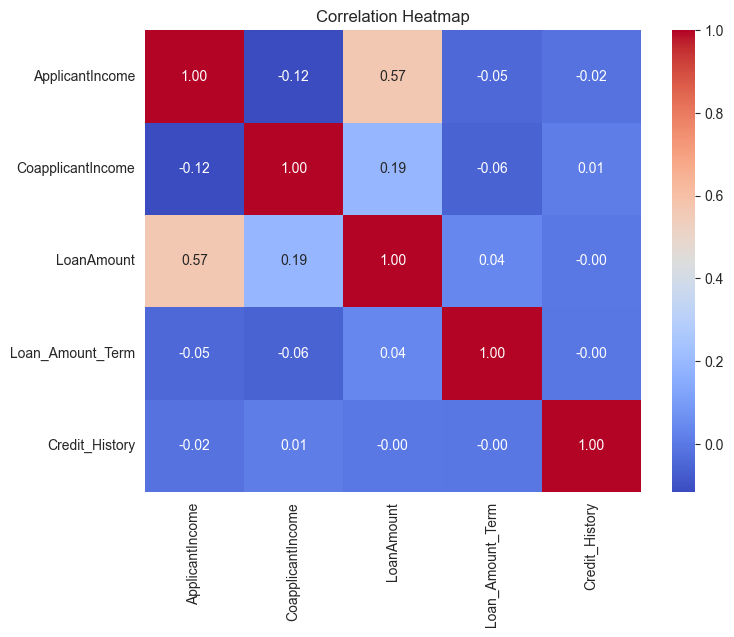

```python
plt.figure(figsize=(8, 6))
sns.heatmap(df.select_dtypes(include=np.number).corr(), annot=True, cmap="coolwarm", fmt=".2f")
plt.title("Correlation Heatmap")
save_file=os.path.join(CHARTS_DIR, 'correlation_heatmap.png')
plt.savefig(save_file, dpi=300, bbox_inches='tight')
print(f"Chart saved to: {save_file}")
plt.show()
```

### Credit History vs Loan Status

```
Chart saved to: p:\loan default prediction\charts\credit_history_vs_loan_status.png
```

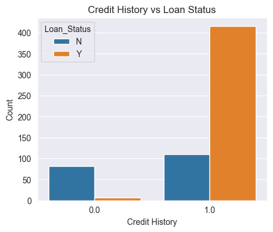

```python
plt.figure(figsize=(5, 4))
sns.countplot(x="Credit_History", hue="Loan_Status", data=df)
plt.title("Credit History vs Loan Status")
plt.xlabel("Credit History")
plt.ylabel("Count")
save_file=os.path.join(CHARTS_DIR, 'credit_history_vs_loan_status.png')
plt.savefig(save_file, dpi=300, bbox_inches='tight')
print(f"Chart saved to: {save_file}")
plt.show()
```

### Income and Loan Amount vs Loan Status

```
Chart saved to: p:\loan default prediction\charts\income_loan_amount_vs_loan_status.png
```

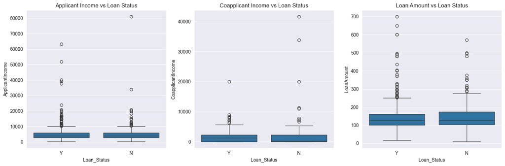

```python
fig, axes = plt.subplots(1, 3, figsize=(15, 5))

sns.boxplot(x="Loan_Status", y="ApplicantIncome", data=df, ax=axes[0])
axes[0].set_title("Applicant Income vs Loan Status")

sns.boxplot(x="Loan_Status", y="CoapplicantIncome", data=df, ax=axes[1])
axes[1].set_title("Coapplicant Income vs Loan Status")

sns.boxplot(x="Loan_Status", y="LoanAmount", data=df, ax=axes[2])
axes[2].set_title("Loan Amount vs Loan Status")

plt.tight_layout()
save_file=os.path.join(CHARTS_DIR, 'income_loan_amount_vs_loan_status.png')
plt.savefig(save_file, dpi=300, bbox_inches='tight')
print(f"Chart saved to: {save_file}")
plt.show()
```

### Loan Approval Rate by Property Area

```
Chart saved to: p:\loan default prediction\charts\loan_approval_rate_by_property.png
```

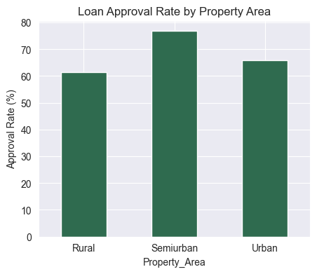

```
Property_Area
Rural        61.5
Semiurban    76.8
Urban        65.8
Name: Loan_Status, dtype: float64
```

```python
approval_rate_area = df.groupby("Property_Area")["Loan_Status"].apply(lambda s: (s == "Y").mean() * 100)
approval_rate_area = approval_rate_area.round(1)

plt.figure(figsize=(5, 4))
approval_rate_area.plot(kind="bar", color="#2F6B4F")
plt.title("Loan Approval Rate by Property Area")
plt.ylabel("Approval Rate (%)")
plt.xticks(rotation=0)
save_file=os.path.join(CHARTS_DIR, 'loan_approval_rate_by_property.png')
plt.savefig(save_file, dpi=300, bbox_inches='tight')
print(f"Chart saved to: {save_file}")
plt.show()

approval_rate_area
```

## Feature Engineering (Exploratory)

It is common practice for this dataset to combine applicant and co-applicant income into a single **Total Income** feature, and to reduce the skew in income values with a log transform. We explore both here to see whether they add insight, using a separate copy of the data (`df_fe`) so the modeling features used later in this notebook are not affected.

```python
df_fe = df.copy()
df_fe["Total_Income"] = df_fe["ApplicantIncome"] + df_fe["CoapplicantIncome"]
df_fe[["ApplicantIncome", "CoapplicantIncome", "Total_Income"]].head()
```

|  | ApplicantIncome | CoapplicantIncome | Total_Income |
| --- | --- | --- | --- |
| 0 | 5849 | 0.0 | 5849.0 |
| 1 | 4583 | 1508.0 | 6091.0 |
| 2 | 3000 | 0.0 | 3000.0 |
| 3 | 2583 | 2358.0 | 4941.0 |
| 4 | 6000 | 0.0 | 6000.0 |

### Total Income vs Loan Status

```
Chart saved to: p:\loan default prediction\charts\total_incomve_vs_loan_status.png
```

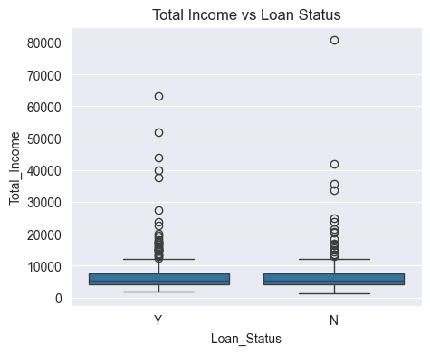

```python
plt.figure(figsize=(5, 4))
sns.boxplot(x="Loan_Status", y="Total_Income", data=df_fe)
plt.title("Total Income vs Loan Status")
save_file=os.path.join(CHARTS_DIR, 'total_incomve_vs_loan_status.png')
plt.savefig(save_file, dpi=300, bbox_inches='tight')
print(f"Chart saved to: {save_file}")
plt.show()
```

### Reducing Skew with a Log Transform

`ApplicantIncome` and `Total_Income` are both strongly right-skewed, as seen in the outlier boxplots earlier. A log transform (`log1p`) pulls in the long tail and makes the distribution closer to normal, which tends to help linear and distance based models.

```
Chart saved to: p:\loan default prediction\charts\total_income_log_transformed.png
```

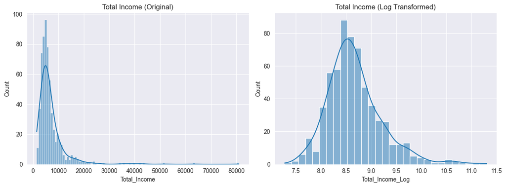

```python
df_fe["Total_Income_Log"] = np.log1p(df_fe["Total_Income"])

fig, axes = plt.subplots(1, 2, figsize=(12, 4.5))

sns.histplot(df_fe["Total_Income"], kde=True, ax=axes[0])
axes[0].set_title("Total Income (Original)")

sns.histplot(df_fe["Total_Income_Log"], kde=True, ax=axes[1])
axes[1].set_title("Total Income (Log Transformed)")

plt.tight_layout()

save_file=os.path.join(CHARTS_DIR, 'total_income_log_transformed.png')
plt.savefig(save_file, dpi=300, bbox_inches='tight')
print(f"Chart saved to: {save_file}")
plt.show()
```

```python
print("Total Income skew before log transform:", round(df_fe["Total_Income"].skew(), 2))
print("Total Income skew after log transform:", round(df_fe["Total_Income_Log"].skew(), 2))
```

```
Total Income skew before log transform: 5.63
Total Income skew after log transform: 1.08
```

**Note:** for this notebook we keep `ApplicantIncome` and `CoapplicantIncome` as separate columns in the final modeling features, so the existing input pipeline (including the custom input test later in this notebook and the Streamlit app's input form) continues to work unchanged. `Total_Income` and the log transform are a valuable direction for a future iteration of the model.

## Key Insights from EDA

- **Class balance:** about 68.7% of applications in this data were approved (`Y`) and 31.3% were not (`N`).
- **Credit history is the dominant signal:** applicants with a credit history were approved 79.0% of the time, versus only 7.9% for those without one. This is by far the strongest relationship found in the data.
- **Property area matters moderately:** Semiurban applicants had the highest approval rate (76.8%), ahead of Urban (65.8%) and Rural (61.5%).
- **Education has a smaller effect:** Graduates were approved 70.8% of the time versus 61.2% for non-graduates.
- **Income alone is a weak predictor:** mean Applicant Income was nearly identical between approved (5,384) and not-approved (5,446) applicants, and the same holds for Total Income (6,889 vs 7,324). Approval does not simply track how much an applicant earns.
- **Income and loan amount are heavily skewed:** Applicant Income has a skew of 6.54 and Total Income 5.63; a log transform brings Total Income's skew down to 1.08, much closer to a normal distribution.
- **Outliers are present** in `ApplicantIncome`, `CoapplicantIncome`, and `LoanAmount`, consistent with the skew above, and are worth keeping in mind for models sensitive to scale and extreme values.

## Encode Categorical Features

We use `LabelEncoder` for each categorical column and store the encoders in a dictionary so the same encoding can be reused during inference in the Streamlit app.

```python
df.dtypes
```

```
Gender                object
Married               object
Dependents            object
Education             object
Self_Employed         object
ApplicantIncome        int64
CoapplicantIncome    float64
LoanAmount           float64
Loan_Amount_Term     float64
Credit_History       float64
Property_Area         object
Loan_Status           object
dtype: object
```

```python
cat_features = ["Gender", "Married", "Dependents", "Education", "Self_Employed", "Property_Area"]

encoders = {}

for col in cat_features:
    le = LabelEncoder()
    df[col] = le.fit_transform(df[col])
    encoders[col] = le

df.head()
```

|  | Gender | Married | Dependents | Education | Self_Employed | ApplicantIncome | CoapplicantIncome | LoanAmount | Loan_Amount_Term | Credit_History | Property_Area | Loan_Status |
| --- | --- | --- | --- | --- | --- | --- | --- | --- | --- | --- | --- | --- |
| 0 | 1 | 0 | 0 | 0 | 0 | 5849 | 0.0 | 128.0 | 360.0 | 1.0 | 2 | Y |
| 1 | 1 | 1 | 1 | 0 | 0 | 4583 | 1508.0 | 128.0 | 360.0 | 1.0 | 0 | N |
| 2 | 1 | 1 | 0 | 0 | 1 | 3000 | 0.0 | 66.0 | 360.0 | 1.0 | 2 | Y |
| 3 | 1 | 1 | 0 | 1 | 0 | 2583 | 2358.0 | 120.0 | 360.0 | 1.0 | 2 | Y |
| 4 | 1 | 0 | 0 | 0 | 0 | 6000 | 0.0 | 141.0 | 360.0 | 1.0 | 2 | Y |

```python
target_encoder = LabelEncoder()
df["Loan_Status"] = target_encoder.fit_transform(df["Loan_Status"])
encoders["Loan_Status"] = target_encoder

# 1=Y and 0=N
df["Loan_Status"].value_counts()
```

```
Loan_Status
1    422
0    192
Name: count, dtype: int64
```

## Saving processed dataset

```python
import os
output_path=os.path.join(DATA_DIR/'processed',"processed_loan_dataset.csv")
df.to_csv(output_path, index=False)
print(f"Processed dataset saved successfully!")
print(f"Dataset shape: {df.shape}")
```

```
Processed dataset saved successfully!
Dataset shape: (614, 12)
```

## Split Dependent and Independent Features

```python
X = df.drop(columns=["Loan_Status"])
y = df["Loan_Status"]

X.head()
```

|  | Gender | Married | Dependents | Education | Self_Employed | ApplicantIncome | CoapplicantIncome | LoanAmount | Loan_Amount_Term | Credit_History | Property_Area |
| --- | --- | --- | --- | --- | --- | --- | --- | --- | --- | --- | --- |
| 0 | 1 | 0 | 0 | 0 | 0 | 5849 | 0.0 | 128.0 | 360.0 | 1.0 | 2 |
| 1 | 1 | 1 | 1 | 0 | 0 | 4583 | 1508.0 | 128.0 | 360.0 | 1.0 | 0 |
| 2 | 1 | 1 | 0 | 0 | 1 | 3000 | 0.0 | 66.0 | 360.0 | 1.0 | 2 |
| 3 | 1 | 1 | 0 | 1 | 0 | 2583 | 2358.0 | 120.0 | 360.0 | 1.0 | 2 |
| 4 | 1 | 0 | 0 | 0 | 0 | 6000 | 0.0 | 141.0 | 360.0 | 1.0 | 2 |

## Train Test Split

```python
X_train, X_test, y_train, y_test = train_test_split(
    X, y, test_size=0.2, random_state=42, stratify=y
)

print("Train shape:", X_train.shape)
print("Test shape:", X_test.shape)
```

```
Train shape: (491, 11)
Test shape: (123, 11)
```

## Feature Scaling

The scaler is fit only on the training data to avoid data leakage, then used to transform both the training and test data.

```python
scaler = StandardScaler()

X_train_scaled = scaler.fit_transform(X_train)
X_test_scaled = scaler.transform(X_test)
```

## Model Training with GridSearchCV

We train five different models and use `GridSearchCV` to find the best hyperparameters for each one. `cv=5` performs 5-fold cross validation.

```python
models_and_params = {
    "Logistic Regression": {
        "model": LogisticRegression(max_iter=1000, random_state=42),
        "params": {
            "C": [0.01, 0.1, 1, 10],
            "solver": ["liblinear"]
        }
    },
    "Random Forest": {
        "model": RandomForestClassifier(random_state=42),
        "params": {
            "n_estimators": [100, 200],
            "max_depth": [None, 5, 10],
            "min_samples_split": [2, 5]
        }
    },
    "SVM": {
        "model": SVC(random_state=42),
        "params": {
            "C": [0.1, 1, 10],
            "kernel": ["linear", "rbf"]
        }
    },
    "KNN": {
        "model": KNeighborsClassifier(),
        "params": {
            "n_neighbors": [3, 5, 7, 9],
            "weights": ["uniform", "distance"]
        }
    },
    "XGBoost": {
        "model": XGBClassifier(eval_metric="logloss", random_state=42),
        "params": {
            "n_estimators": [100, 200],
            "max_depth": [3, 5],
            "learning_rate": [0.01, 0.1]
        }
    }
}
```

```python
results = []
best_estimators = {}

for name, mp in models_and_params.items():
    print(f"Training {name} ...")

    grid = GridSearchCV(
        estimator=mp["model"],
        param_grid=mp["params"],
        cv=5,
        scoring="accuracy",
        n_jobs=-1
    )
    grid.fit(X_train_scaled, y_train)

    best_model = grid.best_estimator_
    best_estimators[name] = best_model

    train_pred = best_model.predict(X_train_scaled)
    test_pred = best_model.predict(X_test_scaled)

    train_acc = accuracy_score(y_train, train_pred)
    test_acc = accuracy_score(y_test, test_pred)

    results.append({
        "Model": name,
        "Best Params": grid.best_params_,
        "Train Accuracy": train_acc,
        "Test Accuracy": test_acc
    })

    print(f"{name} done. Train Accuracy: {train_acc:.4f}, Test Accuracy: {test_acc:.4f}")
    print()
```

```
Training Logistic Regression ...
```

```
Logistic Regression done. Train Accuracy: 0.8004, Test Accuracy: 0.8618

Training Random Forest ...
Random Forest done. Train Accuracy: 0.8065, Test Accuracy: 0.8537

Training SVM ...
SVM done. Train Accuracy: 0.7984, Test Accuracy: 0.8537

Training KNN ...
KNN done. Train Accuracy: 0.8024, Test Accuracy: 0.8537

Training XGBoost ...
XGBoost done. Train Accuracy: 0.8004, Test Accuracy: 0.8537
```

## Compare Model Results

```python
results_df = pd.DataFrame(results)
results_df = results_df.sort_values(by="Test Accuracy", ascending=False).reset_index(drop=True)
results_df
```

|  | Model | Best Params | Train Accuracy | Test Accuracy |
| --- | --- | --- | --- | --- |
| 0 | Logistic Regression | {'C': 0.01, 'solver': 'liblinear'} | 0.800407 | 0.861789 |
| 1 | Random Forest | {'max_depth': 5, 'min_samples_split': 2, 'n_es... | 0.806517 | 0.853659 |
| 2 | SVM | {'C': 0.1, 'kernel': 'linear'} | 0.798371 | 0.853659 |
| 3 | KNN | {'n_neighbors': 9, 'weights': 'uniform'} | 0.802444 | 0.853659 |
| 4 | XGBoost | {'learning_rate': 0.01, 'max_depth': 3, 'n_est... | 0.800407 | 0.853659 |

```
Chart saved to: p:\loan default prediction\charts\model_comparisons.png
```

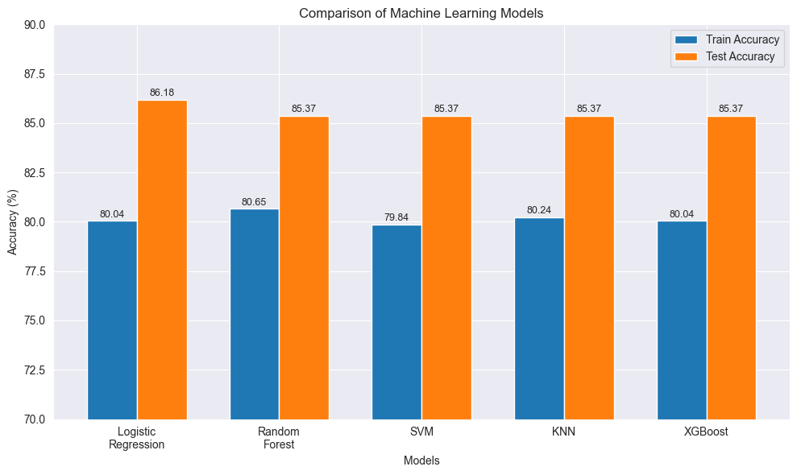

```python
models = [
    "Logistic\nRegression",
    "Random\nForest",
    "SVM",
    "KNN",
    "XGBoost"
]

train_acc = [80.04, 80.65, 79.84, 80.24, 80.04]
test_acc  = [86.18, 85.37, 85.37, 85.37, 85.37]

x = np.arange(len(models))
width = 0.35

plt.figure(figsize=(10,6))

plt.bar(x-width/2, train_acc, width, label="Train Accuracy")
plt.bar(x+width/2, test_acc, width, label="Test Accuracy")

plt.xticks(x, models)
plt.ylabel("Accuracy (%)")
plt.xlabel("Models")
plt.title("Comparison of Machine Learning Models")
plt.ylim(70,90)
plt.legend()

# Add value labels
for i, v in enumerate(train_acc):
    plt.text(i-width/2, v+0.2, f"{v:.2f}", ha='center', fontsize=9)

for i, v in enumerate(test_acc):
    plt.text(i+width/2, v+0.2, f"{v:.2f}", ha='center', fontsize=9)

plt.tight_layout()
save_file=os.path.join(CHARTS_DIR, 'model_comparisons.png')
plt.savefig(save_file, dpi=300, bbox_inches='tight')
print(f"Chart saved to: {save_file}")

plt.show()
```

## Selecting the Best Model

```python
best_model_name = results_df.loc[0, "Model"]
best_model = best_estimators[best_model_name]

print("Best Model:", best_model_name)
print(best_model)
```

```
Best Model: Logistic Regression
LogisticRegression(C=0.01, max_iter=1000, random_state=42, solver='liblinear')
```

### Detailed Evaluation of the Best Model

```python
y_train_pred = best_model.predict(X_train_scaled)
y_test_pred = best_model.predict(X_test_scaled)

print("Training Accuracy:", accuracy_score(y_train, y_train_pred))
print("Test Accuracy:", accuracy_score(y_test, y_test_pred))

print()
print("Confusion Matrix (Test Data):")
print(confusion_matrix(y_test, y_test_pred))

print()
print("Classification Report (Test Data):")
print(classification_report(y_test, y_test_pred))
```

```
Training Accuracy: 0.8004073319755601
Test Accuracy: 0.8617886178861789

Confusion Matrix (Test Data):
[[22 16]
 [ 1 84]]

Classification Report (Test Data):
              precision    recall  f1-score   support

           0       0.96      0.58      0.72        38
           1       0.84      0.99      0.91        85

    accuracy                           0.86       123
   macro avg       0.90      0.78      0.81       123
weighted avg       0.88      0.86      0.85       123
```

## Export the Best Model, Encoders and Scaler

These pickle files will later be loaded inside a Streamlit web app to make predictions on new user input.

```python
with open(BASE_DIR/'models'/'best_model.pkl', "wb") as f:
    pickle.dump(best_model, f)

with open(BASE_DIR/'models'/'scaler.pkl', "wb") as f:
    pickle.dump(scaler, f)


with open(BASE_DIR/'models'/'encoder.pkl', "wb") as f:
    pickle.dump(encoders, f)

print("Model, scaler and encoders saved in the 'models' folder.")
```

```
Model, scaler and encoders saved in the 'models' folder.
```

## Test the Best Model with Custom Input

Change the values below to test the model with your own input. The same encoders and scaler used during training are applied here so the input is processed in exactly the same way.

```python
custom_input = {
    "Gender": "Male",
    "Married": "Yes",
    "Dependents": "0",
    "Education": "Graduate",
    "Self_Employed": "No",
    "ApplicantIncome": 5000,
    "CoapplicantIncome": 1500,
    "LoanAmount": 128,
    "Loan_Amount_Term": 360,
    "Credit_History": 1.0,
    "Property_Area": "Urban"
}

custom_df = pd.DataFrame([custom_input])
custom_df
```

|  | Gender | Married | Dependents | Education | Self_Employed | ApplicantIncome | CoapplicantIncome | LoanAmount | Loan_Amount_Term | Credit_History | Property_Area |
| --- | --- | --- | --- | --- | --- | --- | --- | --- | --- | --- | --- |
| 0 | Male | Yes | 0 | Graduate | No | 5000 | 1500 | 128 | 360 | 1.0 | Urban |

```python
# Encode the categorical fields using the same encoders used during training
# We encode into a copy (custom_encoded) so this cell can be re-run safely
# without trying to encode already-encoded values.
custom_encoded = custom_df.copy()

for col in cat_features:
    custom_encoded[col] = encoders[col].transform(custom_encoded[col])

custom_encoded
```

|  | Gender | Married | Dependents | Education | Self_Employed | ApplicantIncome | CoapplicantIncome | LoanAmount | Loan_Amount_Term | Credit_History | Property_Area |
| --- | --- | --- | --- | --- | --- | --- | --- | --- | --- | --- | --- |
| 0 | 1 | 1 | 0 | 0 | 0 | 5000 | 1500 | 128 | 360 | 1.0 | 2 |

```python
# Scale the input the same way the training data was scaled
custom_scaled = scaler.transform(custom_encoded)

# Predict
prediction = best_model.predict(custom_scaled)[0]
prediction_label = encoders["Loan_Status"].inverse_transform([prediction])[0]

if prediction_label == "Y":
    print("Prediction: Loan Approved")
else:
    print("Prediction: Loan Not Approved")
```

```
Prediction: Loan Approved
```